# COMP41680 ASSIGNMENT 1: Data Collection & Preparation 2016/2017

The project analyses the attributes such as number of hotels, pubs, museums, shopping centers, event and temperature for the most visited places in the world. To do so, the data had to be collected from various sources. As the first step of the data collection the web scrapping technique is used to extract [most visited places in world](http://www.brilliantmaps.com/top-100-tourist-destinations).

The names of the cities and their countries are obtained from web scrapping. This data extracted acts as input to the **Google's Geocode API** to find the geographic coordinates of these cities. This coordinate information assists in finding out the different attributes of the city such as the current temperature, number of hotel, bars, museums and shopping centers present in the city. Also, the number of different event to be held in the current month are extracted.

There are total **four Web APIs** used for this assignment:

**Extra Packages installation:**

1. **html5lib** - for reading of html5 based web pages
2. **pyprind** - for using the progress bar

Note 1 : Please download and install the extra packages specified before executing the code  
Note 2 : It is recommended that each cell is run incremental fashion one by one

## Task_1 : Identify one or more suitable web APIs

Google Geocode API

Weather API of OpenWeatherMap

FourSquare Web API

Eventbrite Web API

## Task_2: Collect the data

```python
#
# Created By:   P R A S H A N T   G A R  G  |  STUDENT ID : 16201447
# Created Date: 31-March-2017
# Copyright:    University College Dublin
# Subject       Data Science in Python
#

# Version:                  00.00.00.01

# Modification history:
# None
```

#### Import of Libraries

```python
import pandas as pd # data manipulation, processing and analysis
import numpy as np # Numerical computing
import matplotlib # for data visualization
import matplotlib.pyplot as plt # for plotting of graphs
import urllib.request as req # data collection
import json # for json parsing and manipulation
from pandas.tools.plotting import scatter_matrix
import pyprind # using progress bar to show the progress of tasks
%matplotlib inline
```

#### Web Scrapping Link and Web APIs Endpoints

```python
# Web Page URL for Extracting most travelled cities in the world
touristDestinations = 'http://www.brilliantmaps.com/top-100-tourist-destinations/'

# End point for Google's Geocode Web API - Fetched Lat Lon for the cities
geocodeAPIEndPoint = 'https://maps.googleapis.com/maps/api/geocode/'

# End point for Weather API of OpenWeatherMap - Fetched Current Temperature
# for the cities with Lat Lon as Input
weatherAPIEndPoint = 'http://api.openweathermap.org/'

# End point for FourSquare Web API which fetches number of Bars, Museums, Shopping Centers
# and
foursquareAPIEndPoint = 'https://api.foursquare.com/'

# End point for Eventbrite Web API which fetches number of events in the present month
# in the city
eventbriteAPIEndPoint = 'https://www.eventbriteapi.com/'
```

#### Web APIs OAuth Token

```python
#API Key for Google's Geocode Web API
api_key_geocode = 'AIzaSyCo0NfMl_cFaGySSYy_37SYaeSLamjZkIw'

#API Key for Weather API of OpenWeatherMap
api_key_temperature = 'f14a7c83a84b6a2c1a6afae2541d2680'

#API ID and Key for FourSquare Web API
api_id_foursquare = 'Y2KYXVOZIILARNFQ5GEDXKRQURIEZTDJXB0JJNXKFNLWD1TJ'
api_key_foursquare = 'DD5Z4T40H2H3LYFSJ2VOV13ATDWVIJNUSCZRC4SOIIBN3NAC'

#API Key for Eventbrite Web API
api_key_events = 'TWYWIXQBNTCYMU5VE6M6'
```

### Step_1: Fetching the Most Travelled Cities in the world

#### Web Scrapping for Extracting Cities

```python
#
# Method Name: [getMostTravelledCities]
# This method fetches the most travelled cities in the world and maps them to a dataframe
# @return dataFrameExtractedCities
#
def getMostTravelledCities():
    try:

        #All the tables from the web page specified in variable touristDestinations are retrieved in the
        #variable tablesFromPage and the top row of every table is made the header for the table
        tableFromPage = pd.read_html(touristDestinations, header=0)

        #The first table in the web page is mapped to the dataframe dataFrameExtractedCities
        dataFrameExtractedCities = tableFromPage[0]

        #The DataFrame is returned
        return dataFrameExtractedCities
    except Exception as e:
        print("Got error, while retrieving most travelled cities" , e)
        return None
```

### Step_2: Fetching the Geographic Coordinates of the City

#### Google's Geocode API called for fetching Latitude and Longitude of the Cities

```python
#
# Method Name: [fetchGeoInfoCities]
# This method fetches the latitude and longitude of the cities retrieved from Step_1
# @param step_1 data
# @return dataFrameExtractedGeoInfo
#
def fetchGeoInfoCities(step1Data):

    #Empty Dataframe with attributes such as Rank, City, Country, Tourist, Latitude, Longitude is created
    dataFrameExtractedGeoInfo = pd.DataFrame({"Rank":[],"City":[],"Country":[],"Tourists":[],"Latitude":[],"Longitude":[]})


    print('\nFetching the Latitude and Longitude for the Cities')
    try:

        # For every city in the list of cities
        for singleDataEntry in step1Data:
            rank = singleDataEntry[0] # Rank of the city from step_1
            city = singleDataEntry[1].replace(" ","") # City name from step_1
            country = singleDataEntry[2].replace(" ","") # Country in which the city is from step_1
            tourists = singleDataEntry[3] # number of tourists travelling to that city from step_1

            #Fetching the Lattitude and Longitude Information from Google Map API
            linkLocation = geocodeAPIEndPoint + 'json?address=' + city + ','+country+"&key=" + api_key_geocode
            responseGeocodeAPI = req.urlopen(linkLocation)
            dataGeocodeAPI = json.load(responseGeocodeAPI)

            # Parsing the json obtained by the API hit and extracting Latitude and Longitude from it
            for item in dataGeocodeAPI['results']:
                lat = item['geometry']['location']['lat']
                lon = item['geometry']['location']['lng']

                # The Latitude and Longitude retrieved are appended to the data retrieved in step_1
                df = pd.DataFrame({"Rank":[rank],"City":[singleDataEntry[1]],"Country":[singleDataEntry[2]],"Tourists":[singleDataEntry[3]],"Latitude":[lat],"Longitude":[lon]})

            # The details of cities is extracted one at a time and appended to the main dataframe
            dataFrameExtractedGeoInfo = pd.concat([dataFrameExtractedGeoInfo,df])

            #  after every city's geographic info is retrieved the progress of the Step_2 operation is updated
            percentageGeo.update()

        #The DataFrame containing the geographic coordinates of all the cities is returned
        return dataFrameExtractedGeoInfo
    except Exception as e:
        print("Got error, while retrieving Latitude and Longitude " , e)
        return None
```

### Step_3: Fetching theTour Attributes Information for the Cities

#### Use of OpenWeather, FourSquare and Eventbrite API to retrieve Tourism Based Attributes for Cities

```python
#
# Method Name: [fetchTourismAttributes]
# This method fetches the Current Temperature; No. of Hotels, Bars, Museums
# ,Shopping Centers and Events in current month on the basis of latitude and longitude
# of the cities retrieved from Step_2
# @param step_2 data
# @return dataFrameExtractedCityAttrs
#
def fetchTourismAttributes(step2Data):

    #Empty Dataframe with attributes such as Rank, City, Country, Tourist, and Tour Based Attributes is created
    dataFrameExtractedCityAttrs = pd.DataFrame({"Rank":[],"City":[],"Country":[],"Tourists":[],"Temperature":[],"Hotels":[],"Bars":[],"Museums":[],"Shopping Centers":[],"Events":[]})

    print('\nFetching the Tourism Based Attributes for the Cities')
    try:

        # For every city in the list of cities
        for singleDataEntry in step2Data:

            rank = singleDataEntry[0] # Rank of the city from step_1
            city = singleDataEntry[1] # City name from step_1
            country = singleDataEntry[2] # Country in which the city is from step_1
            tourists = singleDataEntry[3] # number of tourists travelling to that city from step_1
            latitude = singleDataEntry[4] #Latitude retrieved from step_2
            longitude = singleDataEntry[5] #Longitude retrieved from step_2

            #Fetching the Current Temperature from Weather API of OpenWeatherMap for different Cities
            try:
                linkTemperature = weatherAPIEndPoint + 'data/2.5/weather?' + 'lat=' + str(latitude) +'&lon=' + str(longitude) + '&appid=' + api_key_temperature + '&units=metric'
                responseTemperatureAPI = req.urlopen(linkTemperature)
                dataTemperature = json.load(responseTemperatureAPI)
                # Parsing the json obtained by the API hit and extracting temperature in degree celsius from it
                temperature = dataTemperature['main']['temp']
            except Exception as e:
                dataTemperature = float('NaN')
                print("Couldn't fetch Weather details for the city : ", city  , e)


            #Fetching the Events in Current Month from Eventbrite API for different Cities
            try:
                linkEvents = eventbriteAPIEndPoint + 'v3/events/search/?sort_by=distance&location.latitude=' + str(latitude) + '&location.longitude=' + str(longitude) + '&start_date.keyword=this_month&token=' +api_key_events
                responseEventsAPI = req.urlopen(linkEvents)
                dataEvents = json.load(responseEventsAPI)
                # Parsing the json obtained by the API hit and extracting No.of events in current month from it
                eventsCount = dataEvents['pagination']['object_count']
            except Exception as e:
                eventsCount = float('NaN')
                print("Couldn't fetch Events detail for the city : ", city  , e)


            #Fetching the Museums details from FourSquare Web API for different Cities
            try:
                linkMuseums = foursquareAPIEndPoint + 'v2/venues/explore?v=20161016&ll='+ str(latitude) +'%2C'+ str(longitude) + '&query=museum&client_id=' + api_id_foursquare + '&client_secret=' + api_key_foursquare
                responseMuseums = req.urlopen(linkMuseums)
                dataMuseums = json.load(responseMuseums)
                 # Parsing the json obtained by the API hit and extracting No.of museums in a city
                museumsCount = dataMuseums['response']['totalResults']
            except Exception as e:
                museumsCount = float('NaN')
                print("Couldn't fetch Museums detail for the city : ", city  , e)

            #Fetching the Bar details from FourSquare Web API for different Cities
            try:
                linkBar = foursquareAPIEndPoint + 'v2/venues/explore?v=20161016&ll='+ str(latitude) +'%2C'+ str(longitude) + '&query=bar&client_id=' + api_id_foursquare + '&client_secret=' + api_key_foursquare
                responseBar = req.urlopen(linkBar)
                dataBars = json.load(responseBar)
                 # Parsing the json obtained by the API hit and extracting No.of Bars in a city
                pubsCount = dataBars['response']['totalResults']
            except Exception as e:
                pubsCount = float('NaN')
                print("Couldn't fetch Bars detail for the city : ", city , e)

            #Fetching the Shopping Center details from FourSquare Web API for different Cities
            try:
                linkShoppingCntr = foursquareAPIEndPoint + 'v2/venues/explore?v=20161016&ll='+ str(latitude) +'%2C'+ str(longitude) + '&query=shopping&client_id=' + api_id_foursquare + '&client_secret=' + api_key_foursquare
                responseSC = req.urlopen(linkShoppingCntr)
                dataShoppingCenters = json.load(responseSC)
                 # Parsing the json obtained by the API hit and extracting No.of shopping centers in a city
                scCount = dataShoppingCenters['response']['totalResults']
            except Exception as e:
                scCount = float('NaN')
                print("Couldn't fetch Shopping Centers detail for the city : ", city , e)

            #Fetching the Hotel details from FourSquare Web API for different Cities
            try:
                linkHotel = foursquareAPIEndPoint + 'v2/venues/explore?v=20161016&ll='+ str(latitude) +'%2C'+ str(longitude) +  '&query=hotel&client_id=' + api_id_foursquare + '&client_secret=' + api_key_foursquare
                responseHotel = req.urlopen(linkHotel)
                dataHotels = json.load(responseHotel)
                 # Parsing the json obtained by the API hit and extracting No.of hotels in a city
                hotelsCount = dataHotels['response']['totalResults']
            except Exception as e:
                hotelsCount = float('NaN')
                print("Couldn't fetch Hotels detail for the city :",city , e)


            # The details of cities is extracted one at a time and appended to the main dataframe
            df = pd.DataFrame({"Rank":[rank],"City":[city],"Country":[country],"Tourists":[tourists],"Temperature":[temperature], "Hotels":[hotelsCount],"Bars":[pubsCount],"Museums":[museumsCount],
              "Shopping Centers":[scCount],"Events":[eventsCount]})
            dataFrameExtractedCityAttrs = pd.concat([dataFrameExtractedCityAttrs,df])

            #  after every city's tour attibute info is retrieved the progress of the Step_3 operation is updated
            percentageTourAttr.update()


        #The DataFrame containing the cities tour attributes is returned
        return dataFrameExtractedCityAttrs

    except Exception as e:
        print("Got error, while fetching the Tourism Attributes for the Cities" , e)
        return None
```

## Task 3: Parse the Collected data, and Store it in an appropriate file format

#### Parsing the collected Data

The data retrieved from the Web APIs is in the form of JSON and the parsing of the same is done during **Step_2** and **Step_3** of **Data Collection Task**.

#### Store of Data in the CSV Files

The data is then stored in the csv format

```python
#
# Method Name: [generateCSVGeocodeAPI]
# This method fetches the most travelled cities in the world , it checks the status of table
#  migration before and after its real execution
# @param data represents the data to be stored in the csv file
# @param step denotes step in which the data was extracted from Web API
# @param status nameOfCSV denotes the with which the CSV  file would be stored
# @return True if the CSV is generated successfully otherwise returns False
#
def generateCSVGeocodeAPI(data, step, nameOfCSV):
    try:
        if step is 'geocode':
            #Generating CSV for Step_2 Data Collection Data
            data.to_csv(nameOfCSV, header=True, columns=['Rank','City','Country','Tourists', 'Latitude','Longitude'], index= False)
        elif step is 'tourAttr':
             #Generating CSV for Step_3 Data Collection Data
            data.to_csv(nameOfCSV, header=True, columns=['Rank','City','Country','Tourists', 'Temperature','Hotels','Bars', 'Museums','Shopping Centers', 'Events'], index=False)
        elif step is 'scrap':
             #Generating CSV for Step_1 Data Collection Data
            data.to_csv(nameOfCSV,index = False)
        return True
    except Exception as e:
        print("Some error while generating the CSV : " , nameOfCSV , e)
        return False
```

### Code to execute Task 2 and Task 3 steps

The following code executes the data collection steps of **Task 2** in an incremental fashion and after every step of Data Collection, the data is stored in the CSV format fulfilling the need of **Task 3**

```python
# Web Scrap the Web Page to extract the Most Travelled Cities from it

# The getMostTravelledCities is called to fetch the most travelled cities in the world
citiesDataFrame = getMostTravelledCities()

# If the Step_1 data for Data Collection is extracted successfully
if citiesDataFrame is not None:

    # Rename the attribute Tourists (Millions) to Tourists
    citiesDataFrame = citiesDataFrame.rename(columns={'Tourists (Millions)': 'Tourists'})

    # Generate the CSV file
    scrapCSVgenerated = generateCSVGeocodeAPI(citiesDataFrame,'scrap','scrapped_data.csv')

    # If the Step 1 CSV is generated successfully
    if scrapCSVgenerated:
        print('\n STEP1: C S V   G E N E R A T E D   . . . . . . . . . . ' ,'scrapped_data.csv')
        try:
            # Read the Step1 csv file and extract the data
            csvDataScrp = pd.read_csv('scrapped_data.csv')

            # The extracted data from the csv is converted to array data
            dataDCStep1 = np.array(csvDataScrp)
        except IOError as e:
            print("Got error, while reading the CSV ..Please close the file [scrapped_data.csv] if opened " , e)

    # Intiailize a Progress tracker for Task 1 , Step_2 - retrieval of Lat Lon for the cities
    percentageGeo = pyprind.ProgPercent(len(dataDCStep1),monitor=True)

    # Fetch the Latitude and Longitude of the Cities via fetchGeoInfoCities method
    latLonDataFrame = fetchGeoInfoCities(dataDCStep1)

    # If the Step_2 data for Data Collection is extracted successfully
    if latLonDataFrame is not None:

        # Generate the CSV file
        statusLatLon = generateCSVGeocodeAPI(latLonDataFrame, 'geocode', 'lat_lon_data.csv')

        # If the Step 2 CSV is generated successfully
        if(statusLatLon):
            print('\n STEP2: C S V   G E N E R A T E D   . . . . . . . . . . ' ,'lat_lon_data.csv')
            try:

                # Read the Step2 csv file and extract the data
                csvDataStep1 = pd.read_csv('lat_lon_data.csv')

                # The extracted data from the csv is converted to array data
                dataDCStep2 = np.array(csvDataStep1)

                # Intiailize a Progress tracker for Task 1 , Step_2 - retrieval of Lat Lon for the cities
                percentageTourAttr = pyprind.ProgPercent(len(dataDCStep2),monitor=True)

                # Fetch the Tour Attributes of the Cities via fetchTourismAttributes method
                tourismAttrDataFrame = fetchTourismAttributes(dataDCStep2)

                # If the Step_3 data for Data Collection is extracted successfully
                if tourismAttrDataFrame is not None:

                    # Generate the CSV file
                    statusAttr = generateCSVGeocodeAPI(tourismAttrDataFrame, 'tourAttr', 'finalData.csv')

                    # If the Step 2 CSV is generated successfully
                    if(statusAttr):
                        print('\n STEP3: C S V   G E N E R A T E D   . . . . . . . . . . ' ,'finalData.csv')
                else:
                     print('\nSome error while retrieving data from APIs for Tourism Based Attributes')
            except IOError as e:
                print("Got error, while reading the CSV ..Please close the file [lat_lon_data.csv] if opened " , e)

    # If the Step_2 data for Data Collection is not extracted successfully
    else:
        print('\nSome error while retrieving data using Geocode API')

# If the Step_1 data for Data Collection is not extracted successfully
else:
    print('Please check the Web Scrapping Link')
```

```
 STEP1: C S V   G E N E R A T E D   . . . . . . . . . .  scrapped_data.csv

Fetching the Latitude and Longitude for the Cities
```

```
[100 %] Time elapsed: 00:01:09 | ETA: 00:00:00
Total time elapsed: 00:01:09
```

```
 STEP2: C S V   G E N E R A T E D   . . . . . . . . . .  lat_lon_data.csv

Fetching the Tourism Based Attributes for the Cities
```

```
[100 %] Time elapsed: 00:09:40 | ETA: 00:00:00
```

```
 STEP3: C S V   G E N E R A T E D   . . . . . . . . . .  finalData.csv
```

```
Total time elapsed: 00:09:40
```

## Task 4: Load and represent the data using an appropriate data structure. Apply any pre-processing steps to clean/filter/combine the data

For this assignment,  
though the CSV generated after the final step of the Data Collection is **finalData.csv**, but for analysis purpose I have taken the CSV generated by running this project few days ago, which is **findData_analysis.csv**.

The reason for it, that for every time we run Task 2, the data may vary.

Hence, for maintaining the consistency in the analysed result. This approach is taken.

For examination purpose, **finalData.csv** can be used, by just replacing the;

[nameOfFinalCSV = 'finalData_analysis.csv']

by:

[nameOfFinalCSV = 'finalData.csv']

#### Loading the Data

```python
nameOfFinalCSV = 'finalData_analysis.csv'
```

#### Representing the Data

```python
dataFinal = pd.read_csv(nameOfFinalCSV)
print('\nThe Shape of the DataFrame :: ' , dataFinal.shape)
dataFinal[0:5]
```

```
The Shape of the DataFrame ::  (100, 10)
```

|  | Rank | City | Country | Tourists | Temperature | Hotels | Bars | Museums | Shopping Centers | Events |
| --- | --- | --- | --- | --- | --- | --- | --- | --- | --- | --- |
| 0 | 1 | Hong Kong | Hong Kong | 23.7 | 22.47 | 18 | 238 | 19 | 52 | 8 |
| 1 | 2 | Singapore | Singapore | 21.3 | 24.95 | 40 | 57 | 48 | 246 | 149 |
| 2 | 3 | Bangkok | Thailand | 15.8 | 26.00 | 87 | 70 | 54 | 185 | 7 |
| 3 | 4 | London | UK | 15.5 | 12.91 | 102 | 318 | 30 | 249 | 911 |
| 4 | 5 | Macau | Macau | 13.4 | 22.57 | 39 | 44 | 6 | 22 | 0 |

The data combining is already done from **Task 2** and **Task 3**.

It is seen that final data set we have contains 10 columns and 100 rows.

#### Pre-Processing the Data

- It is quite easily visible that **Rank** attribute doesn't bring any significance in terms of analysis. Hence it is essential to **Filter Out** the **Rank** attribute from the Dataframe

```python
# Dropping the Attribute Rank
dataFinal = dataFinal.drop('Rank',1)
dataFinal[0:5]
```

|  | City | Country | Tourists | Temperature | Hotels | Bars | Museums | Shopping Centers | Events |
| --- | --- | --- | --- | --- | --- | --- | --- | --- | --- |
| 0 | Hong Kong | Hong Kong | 23.7 | 22.47 | 18 | 238 | 19 | 52 | 8 |
| 1 | Singapore | Singapore | 21.3 | 24.95 | 40 | 57 | 48 | 246 | 149 |
| 2 | Bangkok | Thailand | 15.8 | 26.00 | 87 | 70 | 54 | 185 | 7 |
| 3 | London | UK | 15.5 | 12.91 | 102 | 318 | 30 | 249 | 911 |
| 4 | Macau | Macau | 13.4 | 22.57 | 39 | 44 | 6 | 22 | 0 |

- Just like the attribute Rank, attribute **City** plays an important role in the analysis of our data and can unique identify each row in the data set. Hence, **City** attribute is made the index for representation of the dataFrame.

```python
# Setting City as the index to dataFinal DataFrame
dataFinal.set_index(dataFinal.City, inplace=True)

# After setting it as index, Removing it from Axis
dataFinal = dataFinal.drop('City',1)

dataFinal[0:5]
```

| City | Country | Tourists | Temperature | Hotels | Bars | Museums | Shopping Centers | Events |
| --- | --- | --- | --- | --- | --- | --- | --- | --- |
| Hong Kong | Hong Kong | 23.7 | 22.47 | 18 | 238 | 19 | 52 | 8 |
| Singapore | Singapore | 21.3 | 24.95 | 40 | 57 | 48 | 246 | 149 |
| Bangkok | Thailand | 15.8 | 26.00 | 87 | 70 | 54 | 185 | 7 |
| London | UK | 15.5 | 12.91 | 102 | 318 | 30 | 249 | 911 |
| Macau | Macau | 13.4 | 22.57 | 39 | 44 | 6 | 22 | 0 |

- For the analysis purpose, there is a need to have another dataFrame with only numeric data; Hence, we create a new DataFrame **dataNumeric** and store only numeric attributes into them

```python
# The string attribute 'Country' is removed from the dataFinal dataFrame to make it Numerical DataFrame
dataNumeric = dataFinal.drop('Country',1)
dataNumeric[0:5]
```

| City | Tourists | Temperature | Hotels | Bars | Museums | Shopping Centers | Events |
| --- | --- | --- | --- | --- | --- | --- | --- |
| Hong Kong | 23.7 | 22.47 | 18 | 238 | 19 | 52 | 8 |
| Singapore | 21.3 | 24.95 | 40 | 57 | 48 | 246 | 149 |
| Bangkok | 15.8 | 26.00 | 87 | 70 | 54 | 185 | 7 |
| London | 15.5 | 12.91 | 102 | 318 | 30 | 249 | 911 |
| Macau | 13.4 | 22.57 | 39 | 44 | 6 | 22 | 0 |

- Replacing the **NaN values** with some other value for numeric attributes  
  First checking how which all attributes have the NaN values into them

```python
columnsOperation = pd.isnull(dataNumeric).sum()
print("The number of NaN's in Columns of different columns of final dataset  ")
print(columnsOperation)
```

```
The number of NaN's in Columns of different columns of final dataset
Tourists            0
Temperature         0
Hotels              0
Bars                0
Museums             0
Shopping Centers    0
Events              0
dtype: int64
```

In our case, there is not even a single NaN value for any of the column

In case any of the column with numeric values contain NaN values, we need to replace them with a numeric value

For this dataset,it is quite easily visible that the maximum values are relativey high which has caused the mean value to be bit on higher side. So, for this dataset it is appropriate to replace the missing values by the median values of the column

```python
dataNumeric.describe()
```

|  | Tourists | Temperature | Hotels | Bars | Museums | Shopping Centers | Events |
| --- | --- | --- | --- | --- | --- | --- | --- |
| count | 100.000000 | 100.000000 | 100.000000 | 100.000000 | 100.000000 | 100.000000 | 100.000000 |
| mean | 4.476000 | 18.154800 | 90.800000 | 113.140000 | 18.130000 | 76.430000 | 65.100000 |
| std | 4.057618 | 7.663841 | 64.181561 | 89.598208 | 16.149338 | 68.383685 | 163.233829 |
| min | 1.600000 | -4.000000 | 0.000000 | 0.000000 | 0.000000 | 2.000000 | 0.000000 |
| 25% | 2.075000 | 13.627500 | 45.750000 | 43.000000 | 5.750000 | 30.750000 | 1.000000 |
| 50% | 3.000000 | 17.210000 | 73.000000 | 86.500000 | 12.000000 | 47.000000 | 9.500000 |
| 75% | 5.000000 | 25.000000 | 116.000000 | 172.500000 | 27.000000 | 91.250000 | 55.000000 |
| max | 23.700000 | 31.000000 | 294.000000 | 318.000000 | 100.000000 | 250.000000 | 1144.000000 |

Looking at the table, it is quite easily visible that **median** of all the columns is the best value to replace the missing values in individual columns. The **mean** is affected by the outliers

```python
# Replacing the NaN values with Median values for the DataFrame
dataNumeric.fillna(dataNumeric.median(),inplace=True)

# Cleaning the dataFinal too
dataFinal.fillna(dataFinal.median(),inplace=True)

dataNumeric[20:25]
```

| City | Tourists | Temperature | Hotels | Bars | Museums | Shopping Centers | Events |
| --- | --- | --- | --- | --- | --- | --- | --- |
| Las Vegas | 6.3 | 19.79 | 63 | 95 | 10 | 159 | 126 |
| Miami | 6.0 | 28.45 | 48 | 92 | 16 | 184 | 294 |
| Barcelona | 5.5 | 16.50 | 265 | 318 | 36 | 89 | 85 |
| Moscow | 5.0 | -2.25 | 40 | 172 | 100 | 246 | 13 |
| Beijing | 5.0 | 9.00 | 115 | 77 | 12 | 48 | 5 |

Now we have a cleaned & pre-processed data set which is **dataNumeric** dataframe. **dataFinal** dataframe could be used too, but only for processing on attributes such as **Country** and **Tourists**

## Task 5: Analyse and summarise the cleaned dataset

### Dataset Description

```python
# Describing the Numeric DataFrame dataNumeric
dataNumeric.describe()
```

|  | Tourists | Temperature | Hotels | Bars | Museums | Shopping Centers | Events |
| --- | --- | --- | --- | --- | --- | --- | --- |
| count | 100.000000 | 100.000000 | 100.000000 | 100.000000 | 100.000000 | 100.000000 | 100.000000 |
| mean | 4.476000 | 18.154800 | 90.800000 | 113.140000 | 18.130000 | 76.430000 | 65.100000 |
| std | 4.057618 | 7.663841 | 64.181561 | 89.598208 | 16.149338 | 68.383685 | 163.233829 |
| min | 1.600000 | -4.000000 | 0.000000 | 0.000000 | 0.000000 | 2.000000 | 0.000000 |
| 25% | 2.075000 | 13.627500 | 45.750000 | 43.000000 | 5.750000 | 30.750000 | 1.000000 |
| 50% | 3.000000 | 17.210000 | 73.000000 | 86.500000 | 12.000000 | 47.000000 | 9.500000 |
| 75% | 5.000000 | 25.000000 | 116.000000 | 172.500000 | 27.000000 | 91.250000 | 55.000000 |
| max | 23.700000 | 31.000000 | 294.000000 | 318.000000 | 100.000000 | 250.000000 | 1144.000000 |

**Description of the Tourism based attributes of the city.**

1. **City (Index)** - It represents the most travelled cities in the world.
2. **Tourists** - It represents the number of tourists in million who travel to a city.
3. **Temperature** - It represents the current temperature of the city in degree celsius.
4. **Hotels** - It represents the number of hotels in the city.
5. **Bars** - It represents the number of bars in the city.
6. **Museums** - It represents the number of museums in the city.
7. **Shoppping Centers** - It represents the number of shopping centers in the city.
8. **Events** - It represents the number of events in the city in this particular month.

It can be clearly seen that the count of all the tourism based attributes for the cities is 100  
i.e. data is for the 100 most travelled cities in the world.

All the detail extracted for the Cities are generated on runtime and may differ everytime you run the project. The details of their minima, maxima, First Qaurtile, Median, Third Quartile and Standard Deviation may change as well.

### Analysis Based on Grouping by Country Names

#### Countries with Most Number of Famous Cities

In this we will find out the countries which have the maximum number of most visitied places in the world. For this analysis we will use **dataFinal** data frame. The reason is that in **dataNumeric** doesn't have the Country attribute

```
China       9
USA         8
India       6
Thailand    4
Turkey      4
Name: Country, dtype: int64
```

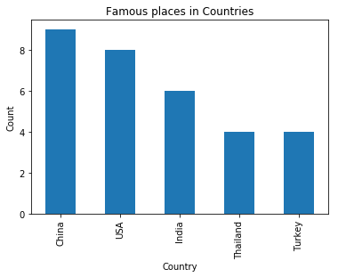

```python
# Grouping on the Basis country and Finding the count
counts = dataFinal["Country"].value_counts()

# Plotting the 5 best countries on the basis of this count
countPlot = counts.head(5).plot(kind="bar")

# Setting the Labels
countPlot.set_xlabel("Country")
countPlot.set_ylabel("Count")

# Setting the Title
countPlot.set_title("Famous places in Countries")

print()
print(counts.head(5))
```

#### Countries with Most Tourists

In this we will find out the countries which have the maximum number of tourists travelling in it. For this analysis we will use **dataFinal** data frame.

```
Country
China        43.7
USA          39.9
Thailand     31.8
Turkey       24.7
Hong Kong    23.7
Name: Tourists, dtype: float64
```

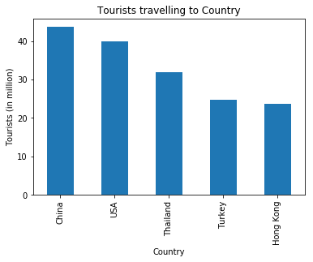

```python
# Grouping on the Basis country and Finding the Tourists
groupCountryTourists = dataFinal.groupby('Country')['Tourists']

# Finding the Sum of the Tourists for every Country
groupCountryTouristsSum = groupCountryTourists.sum()

# Sorting the Countries on the basis of Sum of Tourists
groupCountryTouristsSum.sort_values(ascending=False)

# Select the best 5 countries with most Tourists travelling to it
trimmedData2 = groupCountryTouristsSum.sort_values(ascending=False)[0:5]


# Plotting the 5 best countries on the basis of this sum
sumPlot = trimmedData2.plot(kind='bar')

# Setting the Labels
sumPlot.set_xlabel("Country")
sumPlot.set_ylabel("Tourists (in million)")

# Setting the Title
sumPlot.set_title("Tourists travelling to Country")

print()
print(trimmedData2)
```

### Analysis of 10 Most visited Cities in World

```python
# Displaying top 10 cities in the world
dataNumeric[0:10]
```

| City | Tourists | Temperature | Hotels | Bars | Museums | Shopping Centers | Events |
| --- | --- | --- | --- | --- | --- | --- | --- |
| Hong Kong | 23.7 | 22.47 | 18 | 238 | 19 | 52 | 8 |
| Singapore | 21.3 | 24.95 | 40 | 57 | 48 | 246 | 149 |
| Bangkok | 15.8 | 26.00 | 87 | 70 | 54 | 185 | 7 |
| London | 15.5 | 12.91 | 102 | 318 | 30 | 249 | 911 |
| Macau | 13.4 | 22.57 | 39 | 44 | 6 | 22 | 0 |
| Kuala Lumpur | 13.3 | 25.54 | 85 | 36 | 32 | 225 | 40 |
| Shenzhen | 12.1 | 22.45 | 65 | 37 | 7 | 27 | 1 |
| New York City | 11.6 | 14.15 | 63 | 224 | 28 | 249 | 1144 |
| Antalya | 10.3 | 14.00 | 35 | 21 | 15 | 127 | 0 |
| Paris | 9.8 | 15.00 | 198 | 316 | 27 | 116 | 172 |

**The table above denotes the details of 10 most visited cities in the world.**

**Temperature**  
It can be seen that **Bangkok** is the hottest place with a Temperature of **26 degree celsius** and **London** is the coldest with **12.91 degree celsius** temperature.

**Hotels**  
It is strange to see that, the most visited city **Hong Kong** has **minimum number of Hotels (18)** and **Paris** at the tenth poisition contains the maximum number of hotels i.e. **198** .

**Bars**  
**London** has highest number of **Bars i.e 318** and is closely followed by **Paris with 316**. **Antalya** had just **21 Bars** which was the minimum.

**Museums**  
**Bangkok** has highest number of **Museums i.e 54** and is closely followed by **Singapore with 48**. **Macau** had just **6 Museums** which is the minimum.

**Shopping Centers**  
**Singapore, London, Kaula Lumpur and New York City** have more than **200** shopping centers. Shopping centers are the main attraction for the visiting tourists

**Events**  
Nowadays, tourist while planning their take into consideration about special events scheduled in the country travelling to. Hence, the attribute Events plays a very important part too. **New York City** has highest number of **Events i.e 1144** scheduled to be held for the current month and is closely followed by **London with 911 Events**. **Macau and Antalya** had no event scheduled for the month</b>.

Plotting these attributes over the Cities help us to visualize the data

[output not shown]

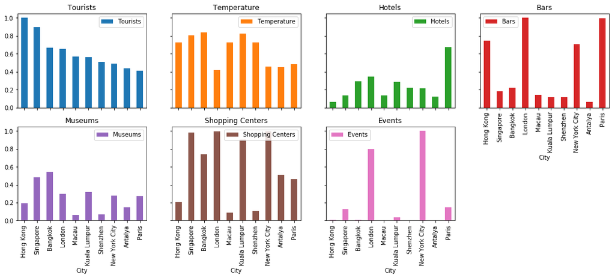

```python
#Normalized the data in the range of [0:1] to give the better view on
normalizedData = dataNumeric/dataNumeric.max()
plotSharey = normalizedData.head(10)
plotSharey.plot(kind='bar',subplots = True,layout = (3,4),figsize=(18, 10), sharey=True)
```

The sub plots above give the graphical representation of tour attributes for the 10 most visited cities in the world.

**It is important to recommend and give an overall analysis of all the tour based attributes for the top 10 cities.**  
**Temperature** and **Tourists** attribute are removed from the data set are they are not important for this particular analysis.

Reason behind removing these attributes:

1. Tourists: The analysis is already done for this attribute in the previous section
2. Temperature: For the collective analysis, it will penalise the cold places as there temperature is lower than that of hot places

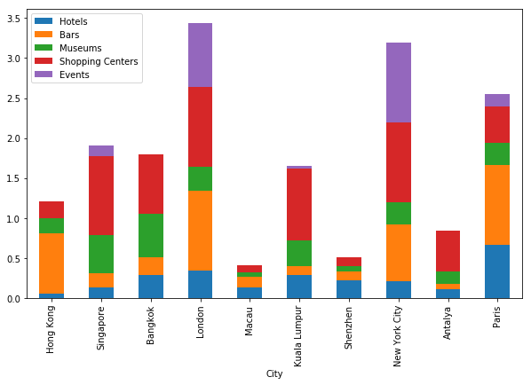

```python
# Dropping Tourists and Temperature
tourAttrData = normalizedData.drop(['Tourists','Temperature'],1)

# Plotting the Stacked Graph for Top 10 Cities
tourAttrData.head(10).plot.bar(stacked=True,figsize=(10, 6))
```

**On the scaling of these 10 cities over the following attributes:**

- Hotel
- Bars
- Museums
- Shopping centers
- Events

It is visible that **London** performs the best by matching the high peak of almost all the five attributes.

On the Lower end, its **Macau and Shenzhen** who score very low points in terms of all these attributes.

### Analysis based on Individual Tour Attributes

In the above section the analysis was made on the comparison of 10 most visited cities over the five different attributes. In this section the analysis would be based on the preference of each individual attribute over the complete data set of most visited cities in the world. For this, even the Temperature attribute will be analyzed

##### Attribute - Hotel

```python
# Select the top three Contries with Maximum hotels
hotel = dataNumeric.sort_values('Hotels', ascending=False)
hotel.Hotels.head(3)
```

```
City
Istanbul    294
Rome        293
Phuket      286
Name: Hotels, dtype: int64
```

**Recommended Cities to visit [user preference: Hotels only]**

1. Istanbul
2. Rome
3. Phuket

##### Attribute - Bar

```python
# Select the top three Contries with Maximum bars
bar = dataNumeric.sort_values('Bars', ascending=False)
bar.Bars.head(3)
```

```
City
London       318
Barcelona    318
Madrid       318
Name: Bars, dtype: int64
```

**Recommended Cities to visit [user preference: Bars only]**

1. London
2. Barcelona
3. Madrid

##### Attribute - Museums

```python
# Select the top three Contries with Maximum Museums
museum = dataNumeric.sort_values('Museums', ascending=False)
museum.Museums.head(3)
```

```
City
Moscow         100
Mexico City     55
Bangkok         54
Name: Museums, dtype: int64
```

**Recommended Cities to visit [user preference: Museums only]**

1. Moscow
2. Mexico City
3. Bangkok

##### Attribute - Shopping Centers

```python
# Select the top three Contries with Maximum Shopping Centers
shoppingCenter = dataNumeric.sort_values('Shopping Centers', ascending=False)
shoppingCenter['Shopping Centers'].head(3)
```

```
City
St Petersburg    250
New York City    249
London           249
Name: Shopping Centers, dtype: int64
```

**Recommended Cities to visit [user preference: Shopping Centers only]**

1. St Petersburg
2. New York City
3. London

##### Attribute - Events

```python
# Select the top three Contries with Maximum events
event = dataNumeric.sort_values('Events', ascending=False)
event.Events.head(3)
```

```
City
New York City      1144
London              911
Washington D.C.     437
Name: Events, dtype: int64
```

**Recommended Cities to visit [user preference: Events only]**

1. New York City
2. London
3. Washington D.C.

##### Attribute - Temperature (Max - Min)

```python
# Select the top three Contries with Min Temperature
tempCold = dataNumeric.sort_values('Temperature')
tempCold.Temperature.head(3)
```

```
City
St Petersburg   -4.00
Moscow          -2.25
Seoul            1.16
Name: Temperature, dtype: float64
```

```python
# Select the top three Contries with Max Temperature
tempHigh = dataNumeric.sort_values('Temperature',ascending=False)
tempHigh.Temperature.head(3)
```

```
City
Jaipur     31.00
Orlando    30.75
Mecca      29.00
Name: Temperature, dtype: float64
```

**Recommended Cities to visit [user preference: Temperature only]**

- Low Temperature Cities
1. St Petersburg
2. Moscow
3. Seoul D.C.
- High Temperature Cities
1. Jaipur
2. Orlando
3. Mecca

### Finding Correlation between the different attributes of Dataset

```python
#Finding correlation between attributes using Pearson's Correlation
normalizedData.corr(method='pearson', min_periods=1)
```

|  | Tourists | Temperature | Hotels | Bars | Museums | Shopping Centers | Events |
| --- | --- | --- | --- | --- | --- | --- | --- |
| Tourists | 1.000000 | 0.094593 | 0.019522 | 0.121775 | 0.234030 | 0.415057 | 0.275397 |
| Temperature | 0.094593 | 1.000000 | -0.039703 | -0.358156 | -0.279310 | -0.110776 | -0.045474 |
| Hotels | 0.019522 | -0.039703 | 1.000000 | 0.383156 | 0.233096 | 0.058948 | 0.004481 |
| Bars | 0.121775 | -0.358156 | 0.383156 | 1.000000 | 0.520748 | 0.402027 | 0.407256 |
| Museums | 0.234030 | -0.279310 | 0.233096 | 0.520748 | 1.000000 | 0.565124 | 0.177751 |
| Shopping Centers | 0.415057 | -0.110776 | 0.058948 | 0.402027 | 0.565124 | 1.000000 | 0.495965 |
| Events | 0.275397 | -0.045474 | 0.004481 | 0.407256 | 0.177751 | 0.495965 | 1.000000 |

The table depicts that there is almost no correlation between number of tourists travelling to number of hotels and temperature in the city.

No. of Shopping Centers in a city have the highest correlation with the number of tourists travelling to a city. It simply meeans that the cities with more shopping centers often attract more tourists to travell to that city.

###### Plotting the graph to view the correlation between Shopping Centers and Tourists travelling to a country

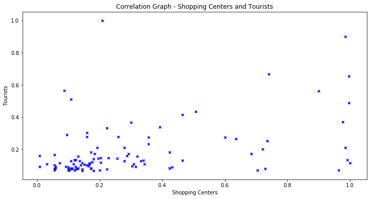

```python
normalizedData.plot(kind="scatter",x="Shopping Centers", y="Tourists",marker='x',color='blue',
                    title="Correlation Graph - Shopping Centers and Tourists",figsize=(12, 6))
```

The Graph above shows the positive correlation between No. of tourists travelling in a city to number of shopping centers present in the city. It is quite easily visible that on increase in the number Shopping centers in a city, there are more tourists travelling to that city.

The other strong positive correlations are between,

Shopping Centers and Museums

The correlation graphs for them are as follows:

###### Correlation Graph between Shopping Centers and Hotels

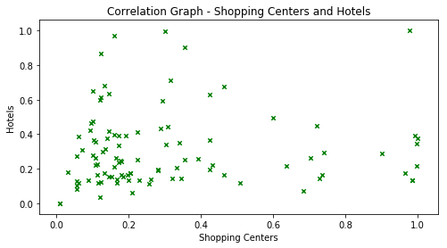

```python
normalizedData.plot(kind="scatter",x="Shopping Centers", y="Hotels",marker='x',color='green',
                    title="Correlation Graph - Shopping Centers and Hotels",figsize=(8, 4))
```

###### Correlation Graph between Shopping Centers and Museums

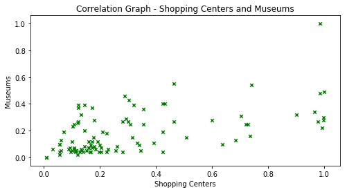

```python
normalizedData.plot(kind="scatter",x="Shopping Centers", y="Museums",marker='x',color='green',
                    title="Correlation Graph - Shopping Centers and Museums",figsize=(8, 4))
```

###### Correlation Graph between Hotels and Museums

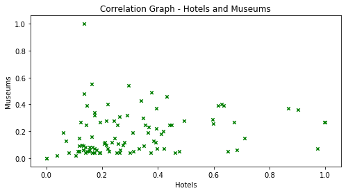

```python
normalizedData.plot(kind="scatter",x="Hotels", y="Museums",marker='x',color='green',
                    title="Correlation Graph - Hotels and Museums",figsize=(8, 4))
```

## Conclusion & Recommendation

The most visited cities in the world were analyzed on the basis of different attributes such as Temperature, number of hotels, bars, museums, shopping centers and number of events scheduled for the current month. It was found that number of hotels in the city didn't have any impact on attracting the tourists. Also, the temperature was not the reason for the tourists to choose their destination.

It was seen that, **China has 9 of the total most visited cities**. This was reason which led the maximum tourists travelling to **China (43.7 million)**.

It was also observed that **London** was the best overall, when comparing the cities on the basis of the Tour Based Attributes.

The average values of the Tour Based Attributes were really on the higher side, which led me to choose Median to fill the missing values if any.

Next, are the recommendation of ten cities to visit to the tourists on the basis of the Tour Based Attributes which are Shopping Centers, Events, Bars, Museums and Hotels.

Since, number of Hotels have no correlation with tourists travelling to a city. I have just considered the number of hotels to be more than the first quartile, for all the other attributes they should be more than the mid values to be considered.

#### Top 10 recommendation made by this Project for Tourists

```python
# Mid point for the DataFrame
selectorMedian = dataNumeric.median()

# 1st Quartile for the DataFrame
selectorQuantile = dataNumeric.quantile(q = 0.25)
```

```python
# Retrieving the records where hotels are more than 1st Quartile, and other attributes such as Bars, Museums,
# Shopping Centers and Events more than the Mid Value
# They are arranged in the order of visiting Toursits to city

recommended = dataNumeric.loc[(dataFinal['Hotels'] >= selectorQuantile['Hotels'])
                                & (dataFinal['Bars'] >= selectorMedian['Bars'])
                             & (dataFinal['Museums'] >= selectorMedian['Museums'])
                             & (dataFinal['Shopping Centers'] >= selectorMedian['Shopping Centers'])
                             & (dataFinal['Events'] >= selectorMedian['Events'])]
```

```python
# Retrieving and displaying the top 10 records of Recommended Cities
recommendedTen = recommended[0:10]
recommendedTen
```

| City | Tourists | Temperature | Hotels | Bars | Museums | Shopping Centers | Events |
| --- | --- | --- | --- | --- | --- | --- | --- |
| London | 15.5 | 12.91 | 102 | 318 | 30 | 249 | 911 |
| New York City | 11.6 | 14.15 | 63 | 224 | 28 | 249 | 1144 |
| Paris | 9.8 | 15.00 | 198 | 316 | 27 | 116 | 172 |
| Rome | 8.7 | 11.86 | 293 | 113 | 27 | 75 | 64 |
| Prague | 6.5 | 14.55 | 145 | 281 | 28 | 150 | 13 |
| Miami | 6.0 | 28.45 | 48 | 92 | 16 | 184 | 294 |
| Barcelona | 5.5 | 16.50 | 265 | 318 | 36 | 89 | 85 |
| Los Angeles | 5.0 | 25.00 | 57 | 113 | 27 | 70 | 356 |
| Budapest | 4.8 | 15.00 | 132 | 303 | 25 | 180 | 30 |
| Amsterdam | 4.3 | 12.99 | 185 | 302 | 40 | 106 | 53 |

```python
# Retrieving and displaying the top 10 records of Most Visited Cities
actualTopTen = dataNumeric[0:10]
actualTopTen
```

| City | Tourists | Temperature | Hotels | Bars | Museums | Shopping Centers | Events |
| --- | --- | --- | --- | --- | --- | --- | --- |
| Hong Kong | 23.7 | 22.47 | 18 | 238 | 19 | 52 | 8 |
| Singapore | 21.3 | 24.95 | 40 | 57 | 48 | 246 | 149 |
| Bangkok | 15.8 | 26.00 | 87 | 70 | 54 | 185 | 7 |
| London | 15.5 | 12.91 | 102 | 318 | 30 | 249 | 911 |
| Macau | 13.4 | 22.57 | 39 | 44 | 6 | 22 | 0 |
| Kuala Lumpur | 13.3 | 25.54 | 85 | 36 | 32 | 225 | 40 |
| Shenzhen | 12.1 | 22.45 | 65 | 37 | 7 | 27 | 1 |
| New York City | 11.6 | 14.15 | 63 | 224 | 28 | 249 | 1144 |
| Antalya | 10.3 | 14.00 | 35 | 21 | 15 | 127 | 0 |
| Paris | 9.8 | 15.00 | 198 | 316 | 27 | 116 | 172 |

#### Comparing Most Visited City with Best Recommended City

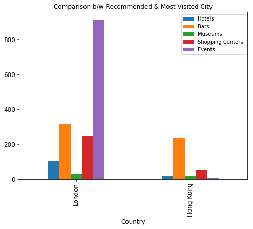

```python
# Framing the first entry of recommended and actual best city
frame = [recommendedTen.head(1), actualTopTen.head(1)]

# Concating the two data frames
concatedFrame = pd.concat(frame)

# Plotting them on the Bar Graph
ax = concatedFrame[['Hotels','Bars','Museums','Shopping Centers','Events']].plot(kind='bar', title ="Comparison b/w Recommended & Most Visited City", figsize=(8,6), legend=True, fontsize=12)

# Setting the Labels
ax.set_xlabel("Country", fontsize=12)
ax.set_ylabel("", fontsize=12)

# Displaying the Graph
plt.show()
```

It is visible that recommended city **London** beats **Hong Kong** (which is the most visited place in the world) in all the aspects of these attributes